# Segmentación Banca

Javier Herráez Albarrán

# Presentación del problema

Una entidad bancaria está interesada en conocer el perfil de los clientes de su cartera respecto a la tenencia y saldo de sus productos de activo y pasivo:

- **PRODUCTOS DE AHORRO**
  - Cuenta a la vista (checkingAccount).- saldo medio en el último año.
  - Depósitos (deposit).- saldo medio en el último año
  - Acciones (shareOfStock).- saldo medio en el último año
  - Planes de pensiones (pensionPlan).- saldo medio en el último año
- **PRODUCTOS DE ACTIVO**
  - Hipotecas (mortgage).- saldo deudor medio en el último año
  - Préstamos personales (loan).- saldo deudor medio en el último año
  - Tarjetas (cards).- importe medio gastado con tarjetas de crédito en el último año
  - Seguros (insurance).- número de seguros contratados (muy vinculado a la tenencia de hipoteca)
- **VINCULACIÓN**
  - Recibos domiciliados (billPayment).- nº medio de recibos domiciliados en el último año
  - Domiciliación nómina (salary).- indicador de tenencia de domiciliación de nómina

# Discretización de variables

Discretizamos las variables en función de sus cuartiles. Además, consideramos los missings values como el hecho de no tener ese determinado producto y por lo tanto, los cambiamos por 0s.

```r
summary(datosBanca)
```

```
##     idClient     checkingAccount       deposit          shareOfStock
##  Min.   :    1   Min.   :  -47639   Min.   :       0   Min.   :      0
##  1st Qu.:24744   1st Qu.:     925   1st Qu.:   13920   1st Qu.:   2499
##  Median :49507   Median :    4640   Median :   33926   Median :  11334
##  Mean   :49473   Mean   :   12619   Mean   :   70407   Mean   :  32126
##  3rd Qu.:74156   3rd Qu.:   13000   3rd Qu.:   74961   3rd Qu.:  31860
##  Max.   :98872   Max.   :54686093   Max.   :74908599   Max.   :2169308
##                  NA's   :601        NA's   :58331      NA's   :60543
##   pensionPlan         mortgage            loan            cards
##  Min.   :      0   Min.   :      0   Min.   : -7022   Min.   :  0.000
##  1st Qu.:   1309   1st Qu.:      0   1st Qu.:     0   1st Qu.:  1.573
##  Median :   7689   Median :  45104   Median :  1993   Median :  7.080
##  Mean   :  21013   Mean   :  83379   Mean   :  9352   Mean   : 11.540
##  3rd Qu.:  25023   3rd Qu.: 125979   3rd Qu.:  9312   3rd Qu.: 16.913
##  Max.   :1307417   Max.   :5531715   Max.   :738865   Max.   :350.067
##  NA's   :55267     NA's   :65776     NA's   :64390    NA's   :26048
##    insurance        billPayment            salary
##  Min.   : 0.0000   Min.   :   0.0000   Min.   :0.0000
##  1st Qu.: 0.0000   1st Qu.:   0.3333   1st Qu.:0.0000
##  Median : 0.0000   Median :   2.6667   Median :1.0000
##  Mean   : 0.4658   Mean   :   3.7913   Mean   :0.6244
##  3rd Qu.: 1.0000   3rd Qu.:   5.3333   3rd Qu.:1.0000
##  Max.   :72.0000   Max.   :2234.0000   Max.   :1.0000
##
```

```r
# Estandarización mediante discretización
datosBanca$checkingAccount_CAT <- discrete_by_quantile(datosBanca$checkingAccount)/4
datosBanca$deposit_CAT <- discrete_by_quantile(datosBanca$deposit)/4
datosBanca$shareOfStock_CAT <- discrete_by_quantile(datosBanca$shareOfStock)/4
datosBanca$pensionPlan_CAT <- discrete_by_quantile(datosBanca$pensionPlan)/4

#datosBanca$mortgage_CAT<-discrete_by_quantile(datosBanca$mortgage)/4
# Como da un error, la asignamos con IF
summary(datosBanca$mortgage)
```

```
##    Min. 1st Qu.  Median    Mean 3rd Qu.    Max.    NA's
##       0       0   45104   83379  125979 5531715   65776
```

```r
datosBanca$mortgage_CAT <- datosBanca$mortgage
datosBanca$mortgage_CAT <- ifelse(datosBanca$mortgage <= 0, 1, datosBanca$mortgage_CAT)
datosBanca$mortgage_CAT <- ifelse(0 < datosBanca$mortgage & datosBanca$mortgage <= 45104, 2, datosBanca$mortgage_CAT)
datosBanca$mortgage_CAT <- ifelse(45104 < datosBanca$mortgage & datosBanca$mortgage <= 125979, 3, datosBanca$mortgage_CAT)
datosBanca$mortgage_CAT <- ifelse(125979 < datosBanca$mortgage, 4, datosBanca$mortgage_CAT)
datosBanca$mortgage_CAT <- datosBanca$mortgage_CAT/4
summary(datosBanca$mortgage_CAT)
```

```
##    Min. 1st Qu.  Median    Mean 3rd Qu.    Max.    NA's
##    0.25    0.25    0.75    0.62    1.00    1.00   65776
```

```r
datosBanca$loan_CAT<-discrete_by_quantile(datosBanca$loan)/4
datosBanca$cards_CAT<-discrete_by_quantile(datosBanca$cards)/4
datosBanca$insurance_CAT<-discrete_by_quantile(datosBanca$insurance)/4
datosBanca$billPayment_CAT<-discrete_by_quantile(datosBanca$billPayment)/4

# La domiciliación de nómina es binaria y no es preciso estandarizarla
# Importante hacerla numérica porque si no, la considera integer y su AVERAGE vía SQL devuelve 0
datosBanca$salary_CAT<-as.numeric(datosBanca$salary)

# Cambiar missings por 0 #
datosBanca$checkingAccount_CAT[is.na(datosBanca$checkingAccount_CAT)]<-0
datosBanca$deposit_CAT[is.na(datosBanca$deposit_CAT)]<-0
datosBanca$shareOfStock_CAT[is.na(datosBanca$shareOfStock_CAT)]<-0
datosBanca$pensionPlan_CAT[is.na(datosBanca$pensionPlan_CAT)]<-0
datosBanca$mortgage_CAT[is.na(datosBanca$mortgage_CAT)]<-0
datosBanca$loan_CAT[is.na(datosBanca$loan_CAT)]<-0
datosBanca$cards_CAT[is.na(datosBanca$cards_CAT)]<-0
datosBanca$insurance_CAT[is.na(datosBanca$insurance_CAT)]<-0
datosBanca$billPayment_CAT[is.na(datosBanca$billPayment_CAT)]<-0

datosBanca.cat <- datosBanca %>%
  select(ends_with('_CAT'))

summary(datosBanca.cat)
```

```
##  checkingAccount_CAT  deposit_CAT     shareOfStock_CAT pensionPlan_CAT
##  Min.   :0.0000      Min.   :0.0000   Min.   :0.0000   Min.   :0.0000
##  1st Qu.:0.2500      1st Qu.:0.0000   1st Qu.:0.0000   1st Qu.:0.0000
##  Median :0.5000      Median :0.0000   Median :0.0000   Median :0.0000
##  Mean   :0.6203      Mean   :0.1641   Mean   :0.1466   Mean   :0.1883
##  3rd Qu.:0.7500      3rd Qu.:0.2500   3rd Qu.:0.0000   3rd Qu.:0.2500
##  Max.   :1.0000      Max.   :1.0000   Max.   :1.0000   Max.   :1.0000
##   mortgage_CAT       loan_CAT        cards_CAT      insurance_CAT
##  Min.   :0.0000   Min.   :0.0000   Min.   :0.0000   Min.   :0.2500
##  1st Qu.:0.0000   1st Qu.:0.0000   1st Qu.:0.0000   1st Qu.:0.2500
##  Median :0.0000   Median :0.0000   Median :0.2500   Median :0.2500
##  Mean   :0.1045   Mean   :0.1148   Mean   :0.4156   Mean   :0.3501
##  3rd Qu.:0.0000   3rd Qu.:0.0000   3rd Qu.:0.7500   3rd Qu.:0.5000
##  Max.   :1.0000   Max.   :1.0000   Max.   :1.0000   Max.   :0.7500
##  billPayment_CAT    salary_CAT
##  Min.   :0.2500   Min.   :0.0000
##  1st Qu.:0.2500   1st Qu.:0.0000
##  Median :0.5000   Median :1.0000
##  Mean   :0.6152   Mean   :0.6244
##  3rd Qu.:0.7500   3rd Qu.:1.0000
##  Max.   :1.0000   Max.   :1.0000
```

Calculamos la matriz de correlaciones de manera que podemos observar que no existe ninguna correlación destacable.

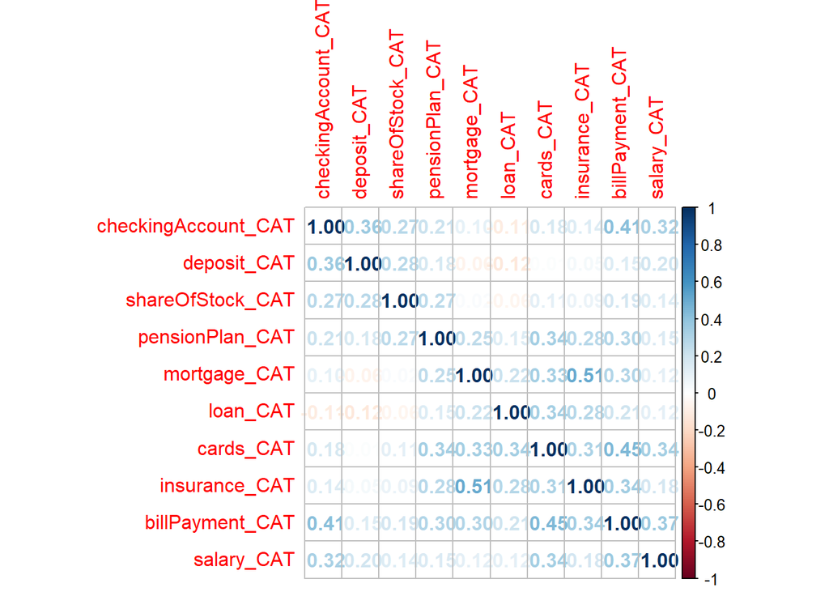

```r
Mcor <- cor(datosBanca.cat,method = c("spearman"))
corrplot(Mcor, method = 'number')
```

# Ajuste bietápico

### Selección del número de Clusters

Para el método bietápico lo primero que haremos será, a través de utilizar un algoritmo jerárquico con una muestra lo suficientemente pequeña de nuestro dataset, determinar el número óptimo de clusters que usaremos más tarde para aplicar el algoritmo k-means sobre nuestro conjunto de datos original.

Por lo tanto, nuestro primer paso será tomar una muestra pequeña del dataset y generaremos un dendograma donde mostraremos el proceso de agrupamiento mediante el método jerárquico Ward.

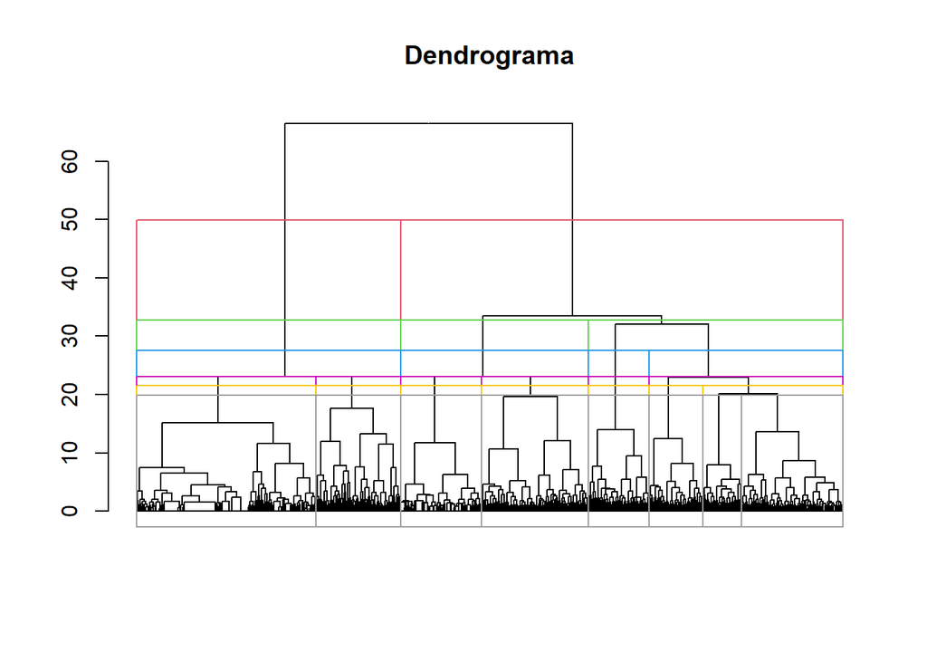

```r
datosBanca.cat.subset <- datosBanca.cat[sample(nrow(datosBanca.cat), nrow(datosBanca.cat) * 0.1), ]
rownames(datosBanca.cat.subset) <- 1:nrow(datosBanca.cat.subset)


matrizDistancias <- vegdist(datosBanca.cat.subset, method = "euclidean")
clusterJerarquico <- hclust(matrizDistancias, method="ward.D2")


plot(as.dendrogram(clusterJerarquico),  main = "Dendrograma", leaflab = 'none')
for (k in 2:8){
  rect.hclust(clusterJerarquico, k=k, border=k)
}
```

Para decidir el númeor de clusters podemos usar varias métricas.

La primera de ellas será el método de Calinski y Harabasz:

```r
calinsky <- cascadeKM(datosBanca.cat.subset, inf.gr = 2, sup.gr = 10, criterion = "calinski", iter = 5)
calinsky$results
```

```
##          2 groups 3 groups 4 groups 5 groups 6 groups 7 groups 8 groups
## SSE      5615.247 4846.715 4302.651 3967.334 3712.532 3425.679 3222.254
## calinski 3106.308 2426.024 2154.822 1919.499 1749.265 1689.865 1610.961
##          9 groups 10 groups
## SSE      3063.731  2990.751
## calinski 1533.433  1417.553
```

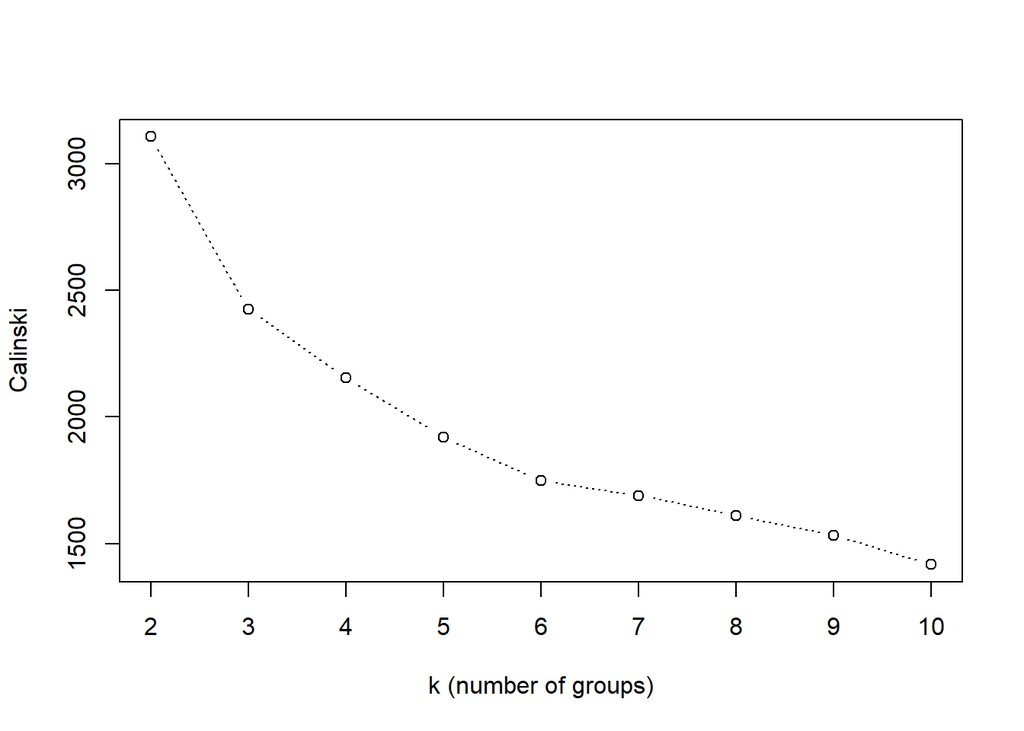

```r
plot(calinsky$results[2,], type = 'b', lty=3, xlab="k (number of groups)", ylab = "Calinski", xaxt='n')
axis(1, seq(1,9), labels = 2:10)
```

También podemos utilizar el coeficiente de silueta para evaluar la bondad del agrupamiento.

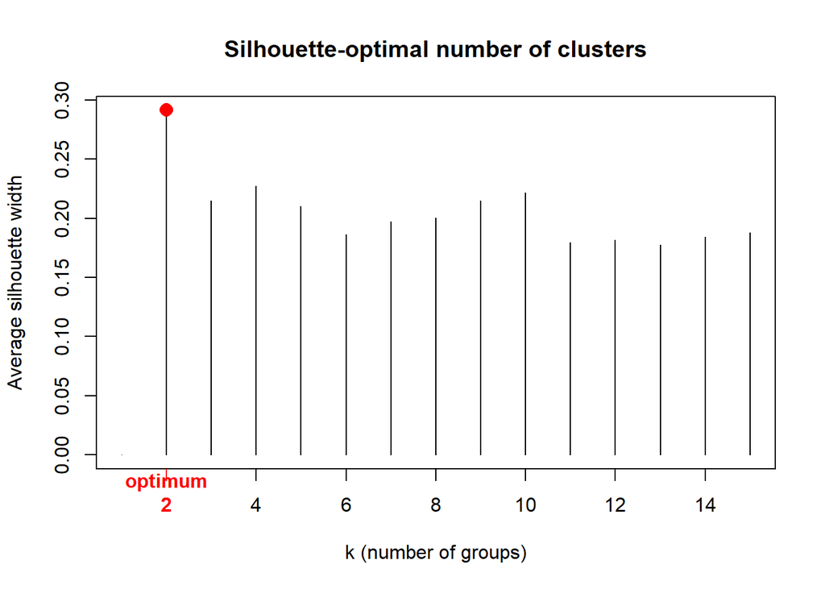

```r
kmax <- 15
asw <- numeric(kmax)
for(k in 2:kmax){
  sil <- silhouette(cutree(clusterJerarquico, k = k), matrizDistancias)
  asw[k] <- summary(sil)$avg.width
  }
k.best <- which.max(asw)

plot(1:kmax, asw, type="h",
     main = "Silhouette-optimal number of clusters",
     xlab = "k (number of groups)", ylab = "Average silhouette width")
axis(1, k.best, paste("optimum", k.best, sep = "\n"), col = "red", font = 2,
     col.axis = "red")
points(k.best, max(asw), pch = 16, col = "red", cex = 1.5)
```

Tras ver los resultados de ambos criterios decidimos utilizar 4 grupos.

### K-means

Calculamos los centroides de los clusters que hemos hecho con la muestra del dataset y k = 4. Tras ello, utilizamos el algoritmo k-means con los centroides que hemos calculado para calcular los grupos para todo nuestro conjunto de datos. Con ello, podemos observar los nuevos centros y el tamaño de nuestros 4 grupos.

```r
asignacionJerarquica <- cbind(datosBanca.cat.subset, cutree(clusterJerarquico, k = 4))

colnames(asignacionJerarquica)[11] <- "cluster"

centroidesJerarquico <-
  asignacionJerarquica %>%
  group_by(cluster) %>%
  summarise(size = n(),
            checkingAccount_CAT = mean(checkingAccount_CAT),
            deposit_CAT = mean(deposit_CAT),
            shareOfStock_CAT = mean(shareOfStock_CAT),
            pensionPlan_CAT = mean(pensionPlan_CAT),
            mortgage_CAT = mean(mortgage_CAT),
            loan_CAT = mean(loan_CAT),
            cards_CAT = mean(cards_CAT),
            insurance_CAT = mean(insurance_CAT),
            billPayment_CAT = mean(billPayment_CAT),
            salary_CAT = mean(salary_CAT)
            )

kmeans <- kmeans(datosBanca.cat, centers=centroidesJerarquico[,3:12])
kmeans$centers
```

```
##   checkingAccount_CAT deposit_CAT shareOfStock_CAT pensionPlan_CAT mortgage_CAT
## 1           0.6628280  0.20211200       0.10594040      0.03408641   0.01882335
## 2           0.4775191  0.06915806       0.07069997      0.08315390   0.04560053
## 3           0.6351488  0.04806130       0.05999608      0.23508153   0.30891747
## 4           0.8614165  0.50709587       0.55663183      0.68879528   0.09704451
##     loan_CAT cards_CAT insurance_CAT billPayment_CAT salary_CAT
## 1 0.02943827 0.2305393     0.3032284       0.5749088  1.0000000
## 2 0.06287179 0.2137878     0.2971242       0.4507773  0.0000000
## 3 0.34116378 0.8432230     0.4630470       0.8013392  0.9462094
## 4 0.05419895 0.6054469     0.3956343       0.8044242  0.8784466
```

```r
kmeans$size
```

```
## [1] 22751 27401 17847 11098
```

También, calcularemos el centroide de todo el dataset para compararlo con cada uno de nuestros clusters.

```r
centroideGeneral <- datosBanca.cat %>%
  summarise(checkingAccount_CAT = mean(checkingAccount_CAT),
            deposit_CAT = mean(deposit_CAT),
            shareOfStock_CAT = mean(shareOfStock_CAT),
            pensionPlan_CAT = mean(pensionPlan_CAT),
            mortgage_CAT = mean(mortgage_CAT),
            loan_CAT = mean(loan_CAT),
            cards_CAT = mean(cards_CAT),
            insurance_CAT = mean(insurance_CAT),
            billPayment_CAT = mean(billPayment_CAT),
            salary_CAT = mean(salary_CAT)
  )
```

Si queremos representar nuestros grupos en un gráfico no podremos hacernos con el conjunto entero, ya que es demasiado grande, pero podemos hacernos una idea con la muestra que habíamos hecho anteriormente.

En este gráfico en 2 dimensiones podemos ver la diferenciación de los grupos con una representatividad de más del 46%.

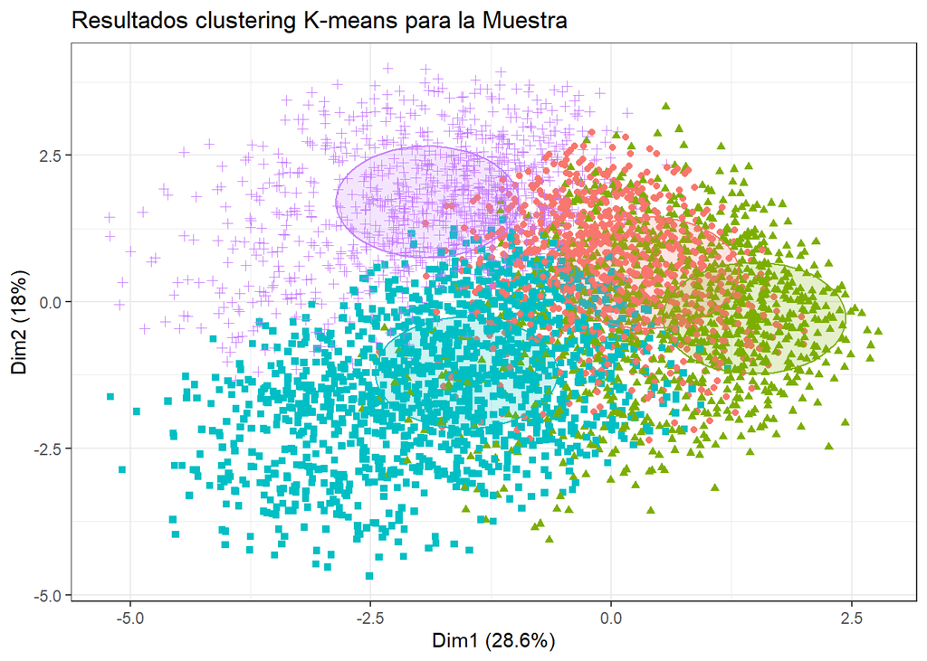

```r
kmeans.subset <- kmeans(datosBanca.cat.subset, centers=centroidesJerarquico[,3:12])

fviz_cluster(object = kmeans.subset, data = datosBanca.cat.subset, show.clust.cent = TRUE,
             ellipse.type = "euclid",
             geom = 'point') +
  labs(title = "Resultados clustering K-means para la Muestra") +
  theme_bw() +
  theme(legend.position = "none")
```

Para analizar los diferentes grupos que hemos obtenido, procedemos a pintar sus centroides sobre una gráfica de radar en comparación de los centroides del dataset completo para poder ver en que destaca cada uno de estos grupos.

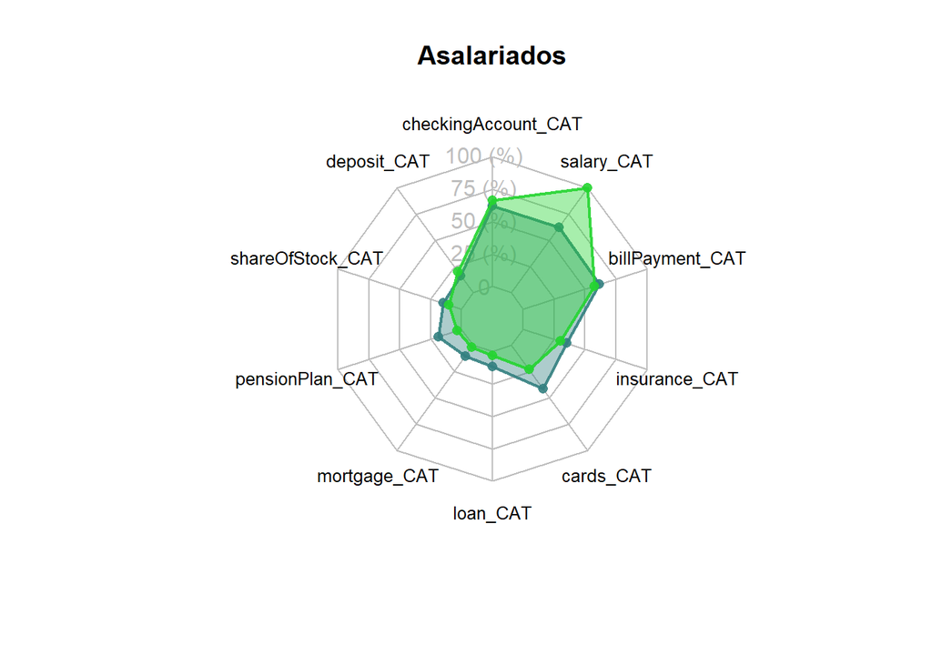

```r
centroidesParaRadar<-rbind(
  rep(1,10) ,
  rep(0,10) ,
  centroideGeneral,
  kmeans$centers)

colors_border = c( rgb(0.2,0.5,0.5,0.9),rgb(0.14,0.83,0.19,0.9))
colors_in = c( rgb(0.2,0.5,0.5,0.4), rgb(0.14,0.83,0.19,0.4))

group <- 1
radarchart( as.data.frame(centroidesParaRadar[c(1:3,3+group),]), axistype=1 ,
            #custom polygon
            pcol = colors_border, pfcol = colors_in, plwd=2, plty=1,
            #custom the grid
            cglcol="grey", cglty=1, axislabcol="grey", caxislabels=seq(0,1,5),
            #custom labels
            vlcex=0.8,
            # title
            title = 'Asalariados'
)
```

El primer grupo destaca por tener a sus clientes con la nómina domiciliada y no tener productos de activo. El resto de productos se mantienen más o menos en la media.